# Univerank

Group 10: NoExcel

1. JARED AVINESH THOMAS (S2132601)
2. MUHYUDDIN AHSAN SULTAN ASKIN (S2119272)
3. DAMIA FATIHAH BINTI IMRAN (U2001010)
4. SAM WEI HONG (U2102776)

#### Shiny App: https://um-samweihong.shinyapps.io/univerank/

#### Github: https://github.com/umSamWeiHong/Univerank

### Introduction

## Problem Statement

###### There are many university ranking systems that are widely available such as the Times Higher Education University Ranking and also QS University Ranking.

###### However, it is difficult for students to make comparisons based on different metrics that exist across different systems.

## Hypothesis

###### If users can compare with all possible metrics, it will make them better informed in choosing their university.

## Approach

###### Creating an interactive experience which generates charts and dashboards for users to visualize comparisons better.

### Development of App

**Back-end Development**

- Datasets which are the QS University Ranking and Times Higher Education Ranking systems were utilized.
- Plotting of features based on ranking, metric, university and country is done on server.R
- Plots will be displayed based on the user's input and preferences

**Front-end Development**

- Layout and appearance of our app is done on ui.R

**Integration**

- Integration of the front-end and back-end were done and executed on Shiny for optimal user experience.

### Description of Application

## Homepage

- Users are greeted with an accesible homepage that immediately gives users the ability to look for the ranking of a university in the 2 systems.

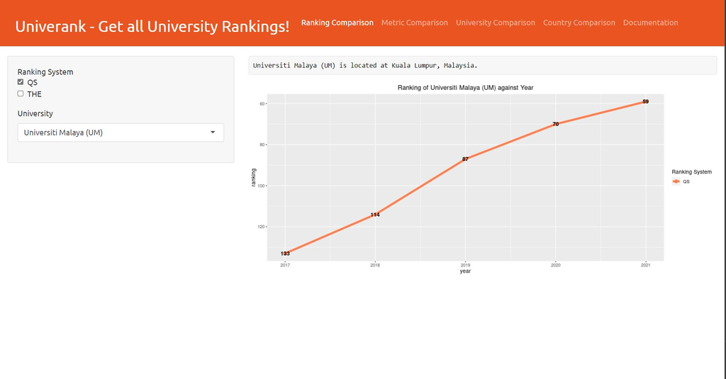

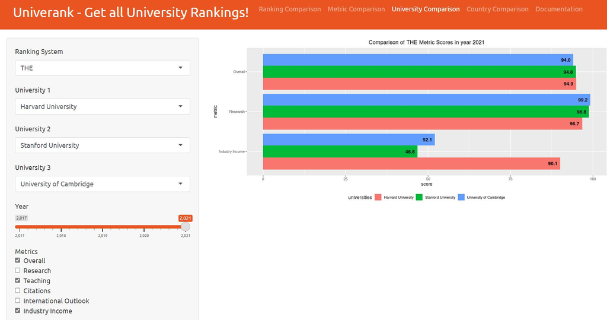

## List of Application Features

- Users have the ability to visit different pages based on different options.
  - Ranking comparisons.
  - Metric comparisons.
  - University comparisons.
  - Country comparisons.
- Users can select and deselect metrics to use in comparison for a more personlized experience.

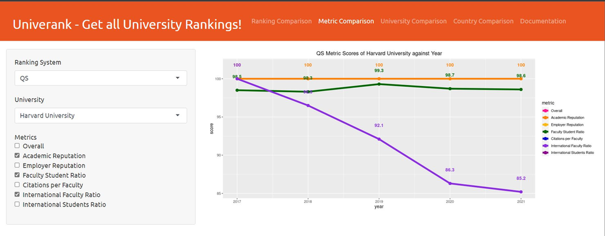

### Summary of Experience

## End-product

- The prototype of this application worked better than expected by visualizing the data for those who are interested in viewing it.
- Extra implementations such as ranking by subject could be implemented for a more layered analysis.

## Challenges

- Shiny is a new application to us therefore we struggled at some parts.
- Hurdles such as errors in code were unavoidable but managed to be debugged in time.

### Key Takeaways

**Acknowledgement of possible solution to problem**

- Different metrics are often messy and are hard to draw comparisons with one another.
- Our application makes it easy for user to see in-depth information on how universities are ranked.

**Suggestions for the Future**

- A centralized ranking system that have unified metrics will be more impactful.
- Metrics should be more friendly to laypeople who do not have deep understanding of data.